# Lecture 4: Confidence Intervals

L2 - Statistics

Gustave Kenedi

2026-02-02

## Recap quiz

[figure not shown]

Or click here: [link to Wooclap](https://app.wooclap.com/L2STATSAMP?from=instruction-slide)

## Today’s lecture

**The big question:** We can compute sample statistics, but how confident should we be that they reflect the true population parameters?

**1. Confidence intervals: a primer**

2. CI for a population mean: theory-based

3. CI for a proportion: theory-based

4. Bootstrap CI

5. Comparing two groups

6. Practical guidelines

# Confidence intervals: a primer

## Why do we need confidence intervals?

**The problem with point estimates:**

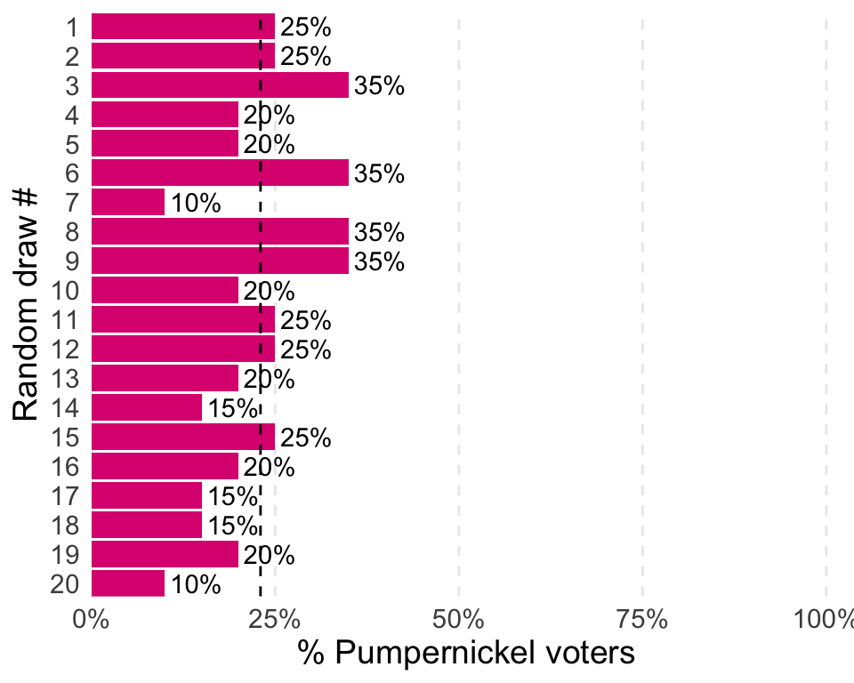

- In real life we only get to take one sample from the population
- Also, we obviously don’t know the true population parameter, that’s what we are interested in!
- Even unobserved, we know that the sampling distribution does exist, and even better, we know how it behaves!

**Key insight:** A single point estimate tells us nothing about how precise or reliable it is!

## From point estimates to confidence intervals

- Until now, we have only estimated point estimates from our samples: sample means, sample proportions, sample variances, etc.
- We know that this sample statistic differs from the true population parameter due to **sampling variation**.
- Rather than a point estimate, we could give a range of plausible values for the population parameter.
- This is precisely what a confidence interval (CI) provides.

## What is a confidence interval?

A **confidence interval** for $\theta$ is an estimated *interval* that covers the true value of $\theta$ with at least a given probability.

*For example:* if we were to take an i.i.d. sample of size $n$ of a random variable $X$ and compute a 95% confidence interval for the population mean $\mathbb{E}[X]$, then with 95% probability, this interval will include $\mathbb{E}[X]$.

**Definition**

A **confidence interval** for $\theta$ with coverage $(1 - \alpha)$ is a random interval $CI_{1-\alpha}(\theta)$, such that $Pr[\theta \in CI_{1-\alpha}(\theta)] \geq 1-\alpha$.

For any given $\alpha \in (0,1)$, we say that the *confidence level* is $100(1-\alpha)\%$ and that $CI_{1-\alpha}(\theta)$ is a $100(1-\alpha)\%$ confidence interval for $\theta$.

## What is a confidence interval?

**Intuition:** Instead of saying “the mean is 65,” we say:

> “We are 95% confident that the true mean lies between 62 and 68”

**Common misconception**

A 95% CI does not mean “there’s a 95% probability the true parameter is in this interval.”

$\rightarrow$ the true parameter is either in the interval or not!

## The correct interpretation

**What 95% confidence actually means:**

If we repeated our sampling procedure many times and computed a CI each time, 95% of those intervals would contain the true parameter.

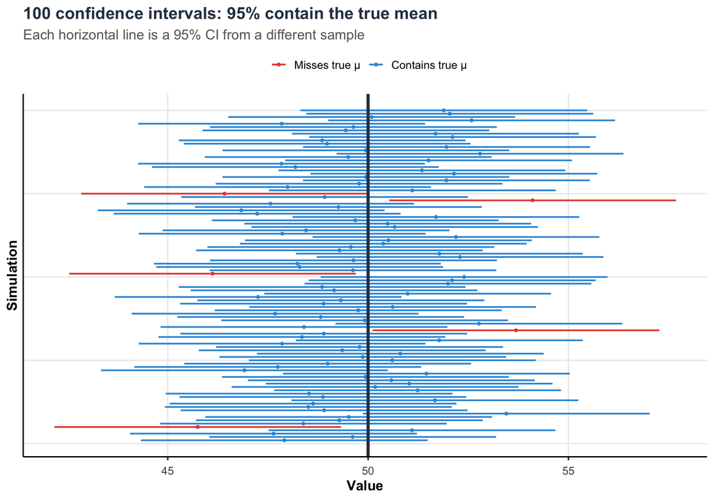

## Constructing confidence intervals

There are several approaches to constructing confidence intervals:

1. *Theory:* use mathematical formulas (Central Limit Theorem) to derive the sampling distribution of our point estimate under certain conditions $\rightarrow$ what R does under the hood!
2. *Simulation:* use the bootstrapping method to reconstruct the sampling distribution of our point estimate

We will cover both methods in this lecture. Let’s start with theory and then cover bootstrap.

## The anatomy of a confidence interval

$$\text{CI} = {\color{#648FFF}{\text{Point Estimate}}} \pm \color{#DC267F}{\text{Margin of Error}}$$
where:

$${\color{#DC267F}{\text{Margin of Error}}} = {\color{#785EF0}{\text{Critical Value}}} \times \color{#FFB000}{\text{Standard Error}}$$

**Components:**

- **Point estimate**: our best guess (e.g., $\bar{x}$, $\hat{p}$)
- **Margin of error**: accounts for sampling variability
- **Critical value**: depends on **confidence level** (e.g., 1.96 for 95%)
- **Standard error**: estimated standard deviation of the sampling distribution

## Where do critical values come from?

For a $(1-\alpha)$% confidence interval, we need to find $z_{\alpha/2}$ such that the middle $(1-\alpha)$ of the standard normal distribution lies between $-z_{\alpha/2}$ and $+z_{\alpha/2}$.

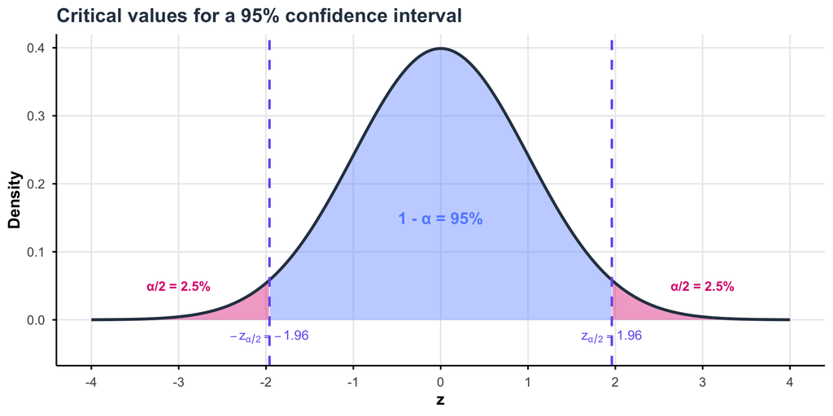

## Why $z_{\alpha/2}$?

We want to construct an interval that captures the true parameter with probability $1-\alpha$ (e.g., if $\alpha = 0.05 \rightarrow 95\%$).

**The notation:** $z_p$ denotes the z-value with probability $p$ in the upper tail:

$$P(Z > z_p) = p$$

**The logic:**

1. We split the “error probability” $\alpha$ equally between both tails of the distribution
2. Each tail gets $\alpha/2$ of the probability
3. So we need $z_{\alpha/2}$: the z-value with $\alpha/2$ probability in the upper tail

```r
# z_{0.025}: 2.5% in upper tail
qnorm(1 - 0.025)  # = qnorm(0.975)
```

```
[1] 1.959964
```

```r
# -z_{0.025}: 2.5% in lower tail
qnorm(0.025)
```

```
[1] -1.959964
```

## Why not $z_{\alpha}$?

What if we used $z_{\alpha}$ instead of $z_{\alpha/2}$?

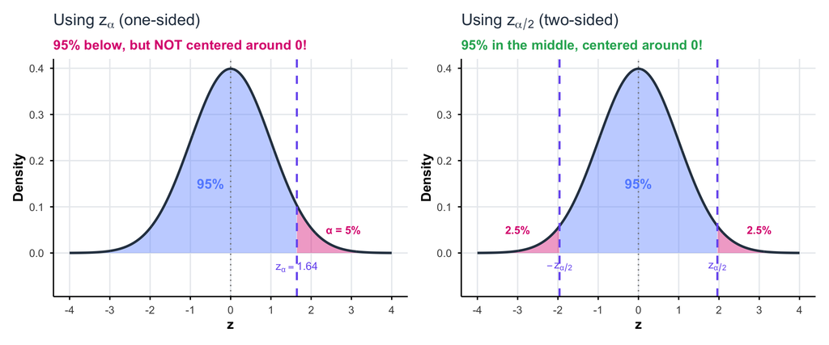

For a symmetric confidence interval around our estimate, we need to split $\alpha$ between **both** tails → use $z_{\alpha/2}$!

## Confidence level: a trade-off

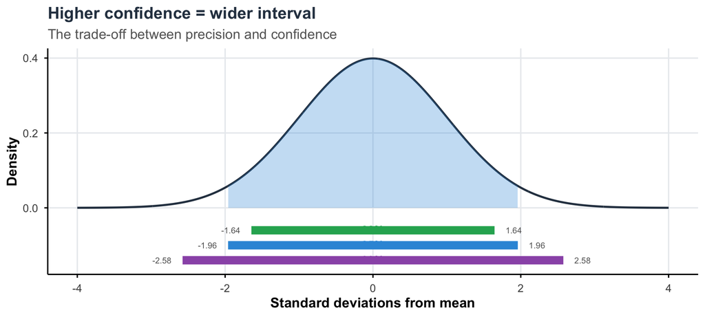

| Confidence Level | Critical Value ($z^*$) | Margin of Error |
| --- | --- | --- |
| 90% | 1.645 | Narrower |
| 95% | 1.960 | Medium |
| 99% | 2.576 | Wider |

## Today’s lecture

**The big question:** We can compute sample statistics, but how confident should we be that they reflect the true population parameters?

1. Confidence intervals: a primer

**2. CI for a population mean: theory-based**

3. CI for a proportion: theory-based

4. Bootstrap CI

5. Comparing two groups

6. Practical guidelines

# CI for a population mean: theory-based

## CI for a population mean ($\sigma$ known)

**Setting:** $X_1, \ldots, X_n$ i.i.d. with unknown mean $\mu$ and known variance $\sigma^2$

By the CLT, for large $n$:
$$\bar{X}_n \sim \mathcal{N}\left(\mu, \frac{\sigma^2}{n}\right)$$

**95% Confidence Interval for $\mu$ ($\sigma$ known)**

$$\bar{x} \pm 1.96 \times \frac{\sigma}{\sqrt{n}}$$

**General formula for $(1-\alpha)$% CI:**
$$\bar{x} \pm z_{\alpha/2} \times \frac{\sigma}{\sqrt{n}}$$

where $z_{\alpha/2}$ is the $(1-\alpha/2)$ quantile of $\mathcal{N}(0,1)$

## Why does this formula work?

We know that $\frac{\bar{X} - \mu}{\sigma/\sqrt{n}} \sim \mathcal{N}(0,1)$, so by definition of $z_{\alpha/2}$:

$$1 - \alpha = \mathbb{P}\left( -z_{\alpha/2} \leq \frac{\bar{X} - \mu}{\sigma / \sqrt{n}} \leq z_{\alpha/2} \right)$$

Now we solve for $\mu$ in the inequalities:

$$= \mathbb{P}\left( -z_{\alpha/2} \frac{\sigma}{\sqrt{n}} \leq \bar{X} - \mu \leq z_{\alpha/2} \frac{\sigma}{\sqrt{n}} \right)$$

$$= \mathbb{P}\left( -\bar{X} - z_{\alpha/2} \frac{\sigma}{\sqrt{n}} \leq - \mu \leq -\bar{X} + z_{\alpha/2} \frac{\sigma}{\sqrt{n}} \right)$$

$$= \mathbb{P}\left( \bar{X} - z_{\alpha/2} \frac{\sigma}{\sqrt{n}} \leq \mu \leq \bar{X} + z_{\alpha/2} \frac{\sigma}{\sqrt{n}} \right)$$

We therefore have: $\boxed{\mathbb{P}\left( \bar{X} - z_{\alpha/2} \frac{\sigma}{\sqrt{n}} \leq \mu \leq \bar{X} + z_{\alpha/2} \frac{\sigma}{\sqrt{n}} \right) = 1 - \alpha}$

This shows that the interval $\left[ \bar{X} - z_{\alpha/2} \frac{\sigma}{\sqrt{n}}, \bar{X} + z_{\alpha/2} \frac{\sigma}{\sqrt{n}} \right]$ contains $\mu$ with probability $1 - \alpha$. ✓

**Problem:** A sample of $n = 36$ students has a mean grade of $\bar{x} = 11$. Assuming grades have a known standard deviation $\sigma = 2$, compute a 95% CI for the population mean.

**Manual calculation:**

$$11 \pm 1.96 \times \frac{2}{\sqrt{36}} = [10.347, 11.653]$$

**Using R directly:**

```r
# Given values
x_bar <- 11
sigma <- 2
n <- 36
alpha <- 0.05

# Critical value
z_crit <- qnorm(1 - alpha/2)

# Standard error
se <- sigma / sqrt(n)

# Margin of error
me <- z_crit * se

# Confidence interval
c(x_bar - me, x_bar + me)
```

```
[1] 10.34668 11.65332
```

## CI for a population mean ($\sigma$ unknown)

**The realistic case:** We almost never know $\sigma$!

**Solution:** Replace $\sigma$ with the sample standard deviation $s$

$$s = \sqrt{\frac{1}{n-1}\sum_{i=1}^{n}(x_i - \bar{x})^2}$$

As we saw last week, our standardized statistic follows a **t-distribution** with $n-1$ degrees of freedom:

$$\frac{\bar{X}_n - \mu}{s/\sqrt{n}} \sim t_{n-1}$$

## The t-distribution: a reminder

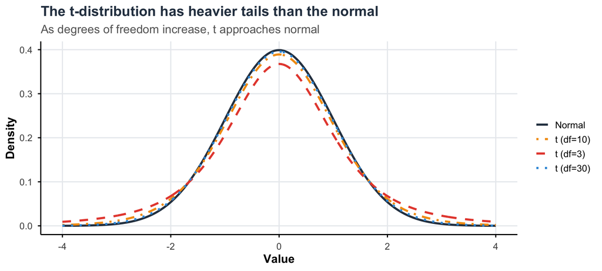

**Key insight:** Heavier tails → wider CIs → accounts for uncertainty in estimating $\sigma$

## Student’s t critical values table

Critical values t for two-sided confidence intervals

| df | 90% (α = 0.10) | 95% (α = 0.05) | 99% (α = 0.01) |
| --- | --- | --- | --- |
| 1 | 6.314 | 12.706 | 63.657 |
| 2 | 2.920 | 4.303 | 9.925 |
| 3 | 2.353 | 3.182 | 5.841 |
| 4 | 2.132 | 2.776 | 4.604 |
| 5 | 2.015 | 2.571 | 4.032 |
| 10 | 1.812 | 2.228 | 3.169 |
| 15 | 1.753 | 2.131 | 2.947 |
| 20 | 1.725 | 2.086 | 2.845 |
| 25 | 1.708 | 2.060 | 2.787 |
| 30 | 1.697 | 2.042 | 2.750 |
| 50 | 1.676 | 2.009 | 2.678 |
| 100 | 1.660 | 1.984 | 2.626 |
| ∞ (Normal) | 1.645 | 1.960 | 2.576 |

**In R:** Use `qt(1 - α/2, df)` to get critical values, e.g., `qt(0.975, df = 29)` for 95% CI with n = 30.

## CI formula with t-distribution

**$(1-\alpha)$% Confidence Interval for $\mu$ ($\sigma$ unknown)**

$$\boxed{\bar{x} \pm t_{\alpha/2, n-1} \times \frac{s}{\sqrt{n}}}$$

where $t_{\alpha/2, n-1}$ is the $(1-\alpha/2)$ quantile of $t_{n-1}$

**In R:**

```r
# Critical value for 95% CI with n=30
qt(0.975, df = 29)
```

```
[1] 2.04523
```

**Note:** For $n > 30$, $t_{n-1} \approx \mathcal{N}(0,1)$, so using $z$ instead of $t$ is often acceptable.

## Real data example: European Social Survey

```r
# Load ESS France data
# In practice, download from https://ess.sikt.no/en/country/321b06ad-1b98-4b7d-93ad-ca8a24e8788a/fr/
ess_france <- read.csv("https://www.dropbox.com/scl/fi/25h4lezq3zuzla94ejmqq/ess_france_11ed.csv?rlkey=lf23ra0i6bvq5dzgtt2u1gy9a&dl=1")
```

```r
# Summary statistics
ess_france |>
  count(stflife)
```

```
   stflife   n
1        0  41
2        1  22
3        2  47
4        3  70
5        4  70
6        5 193
7        6 166
8        7 336
9        8 444
10       9 202
11      10 147
12      77  10
13      88  23
```

```r
ess_france_clean <-  ess_france |>
  filter(!stflife %in% c(77,88))

ess_france_clean |>
  summarise(n = n(),
            mean_life_satisfaction = mean(stflife),
            sd_life_satis = sd(stflife))
```

```
     n mean_life_satisfaction sd_life_satis
1 1738               6.765823      2.294356
```

## Computing the CI in R

**Method 1: Manual calculation**

```r
# Extract summary stats
n <- nrow(ess_france_clean)
x_bar <- mean(ess_france_clean$stflife)
s <- sd(ess_france_clean$stflife)
se <- s / sqrt(n)

# Critical value for 95% CI
t_crit <- qt(0.975, df = n - 1)

# Confidence interval
ci_lower <- x_bar - t_crit * se
ci_upper <- x_bar + t_crit * se

c(ci_lower, ci_upper)
```

```
[1] 6.657882 6.873764
```

**Method 2: Using `t.test()`**

```r
t.test(ess_france_clean$stflife, conf.level = 0.95)$conf.int
```

```
[1] 6.657882 6.873764
attr(,"conf.level")
[1] 0.95
```

## Visualizing the result

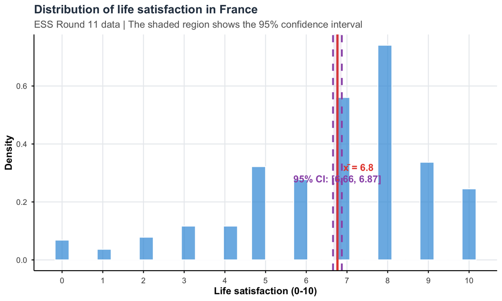

## Interpretation

**Interpretation**

We are **95% confident** that the true average life satisfaction for adults in France is between 6.7 and 6.9 (on a 0-10 scale).

**What this means practically:**

- Life satisfaction is measured on a scale from 0 (extremely dissatisfied) to 10 (extremely satisfied)
- The average French respondent reports being fairly satisfied with life

**Remember:** The confidence is about the *procedure*, not this specific interval!

## Your turn! #1

1. Load the ESS Round 11 data for France

```r
ess_france <- read.csv("https://www.dropbox.com/scl/fi/25h4lezq3zuzla94ejmqq/ess_france_11ed.csv?rlkey=lf23ra0i6bvq5dzgtt2u1gy9a&dl=1")
```

2. Read the documentation on the *Trust in politicians* `trstplt` variable [here](https://ess.sikt.no/en/datafile/242aaa39-3bbb-40f5-98bf-bfb1ce53d8ef?tab=1&elems=12407541-8d0a-4bb6-bc2c-a0ac056dc0ba). Drop the values corresponding refusal, don’t know and no answer.
3. Compute the sample mean trust in politicians, the sample standard deviation and the standard error.
4. Find the critical value for a 90% confidence interval.
5. Compute the 90% confidence interval manually.
6. Use the `t.test()` command to compute the 90% confidence interval directly.
7. Interpret your results.

## Today’s lecture

**The big question:** We can compute sample statistics, but how confident should we be that they reflect the true population parameters?

1. Confidence intervals: a primer

2. CI for a population mean: theory-based

**3. CI for a proportion: theory-based**

4. Bootstrap CI

5. Comparing two groups

6. Practical guidelines

# CI for a proportion: theory-based

## From means to proportions

**Setting:** We want to estimate a population proportion $p$

Examples:

- What proportion of French adults support the EU?
- What percentage of Americans trust the government?
- What fraction of voters will vote for candidate X?

**Key insight:** A proportion is just a mean of 0s and 1s!

If $X_i \in \{0, 1\}$ with $P(X_i = 1) = p$, then:
$$\hat{p} = \bar{X} = \frac{\text{number of successes}}{n}$$

## Sampling distribution of proportions

Since $X_i \sim \text{Bernoulli}(p)$:

- $\mathbb{E}[X_i] = p$
- $\mathbb{V}(X_i) = p(1-p)$

By the CLT (for large $n$):

$$\hat{p} \sim \mathcal{N}\left(p, \frac{p(1-p)}{n}\right)$$

**Standard Error of a Proportion**

$$SE(\hat{p}) = \sqrt{\frac{\hat{p}(1-\hat{p})}{n}}$$

## CI for a proportion

**$(1-\alpha)$% Confidence Interval for p**

$$\hat{p} \pm z_{\alpha/2} \times \sqrt{\frac{\hat{p}(1-\hat{p})}{n}}$$

**Rule of thumb for CLT validity:**

- $n\hat{p} \geq 10$ and $n(1-\hat{p}) \geq 10$

**Caution**

For small samples or extreme proportions (close to 0 or 1), other methods may be more appropriate.

## Example: Interpersonal Trust

Using ESS data, let’s estimate the proportion of French respondents who have high interpersonal trust (i.e., believe most people can be trusted).

```r
# Create binary variable for high trust (> 5 on 0-10 scale)
# Filter out refusals (77), don't know (88), and no answer (99)
ess_trust_prop <- ess_france |>
  filter(!ppltrst %in% c(77, 88)) |>
  mutate(high_trust = ppltrst > 5)

# Compute proportion and CI
n_trust <- nrow(ess_trust_prop)
p_hat <- mean(ess_trust_prop$high_trust)
se_p <- sqrt(p_hat * (1 - p_hat) / n_trust)
z_crit <- qnorm(0.975)

ci_p_lower <- p_hat - z_crit * se_p
ci_p_upper <- p_hat + z_crit * se_p

p_hat
```

```
[1] 0.3198864
```

```r
c(ci_p_lower, ci_p_upper)
```

```
[1] 0.2980952 0.3416775
```

## Using `binom.confint()` in R

```r
# Alternative: prop.test (no specific correction applied)
library(binom)
binom.confint(x = sum(ess_trust_prop$high_trust),
              n = n_trust,
              methods = "asymptotic")
```

```
      method   x    n      mean     lower     upper
1 asymptotic 563 1760 0.3198864 0.2980952 0.3416775
```

```r
# manual CI
c(ci_p_lower, ci_p_upper)
```

```
[1] 0.2980952 0.3416775
```

```r
# a common method: prop.test
prop.test(sum(ess_trust_prop$high_trust), n_trust, conf.level = 0.95)$conf.int
```

```
[1] 0.2982293 0.3423382
attr(,"conf.level")
[1] 0.95
```

**Note:** `prop.test()` uses the [Wilson score interval](https://en.wikipedia.org/wiki/Binomial_proportion_confidence_interval#Wilson_score_interval), which is generally more accurate than the [Wald interval](https://en.wikipedia.org/wiki/Binomial_proportion_confidence_interval#Problems_with_using_a_normal_approximation_or_%22Wald_interval%22) we computed manually.

## Your turn! #2

1. Create education groups and a binary variable for high interpersonal trust (`ppltrst > 5`):

```r
ess_trust_educ <- ess_france |>
  filter(!ppltrst %in% c(77, 88),
         !is.na(education)) |>
  mutate(high_trust = ppltrst > 5)
```

2. Compute the proportion with high trust for each education group.
3. Compute the standard error for each proportion.
4. Compute 95% CIs for each education group.
5. Create a visualization showing point estimates and CIs.
6. Based on the CIs, do you think there are “true” differences in interpersonal trust across education levels? Why or why not?

## Comparing proportions across education levels

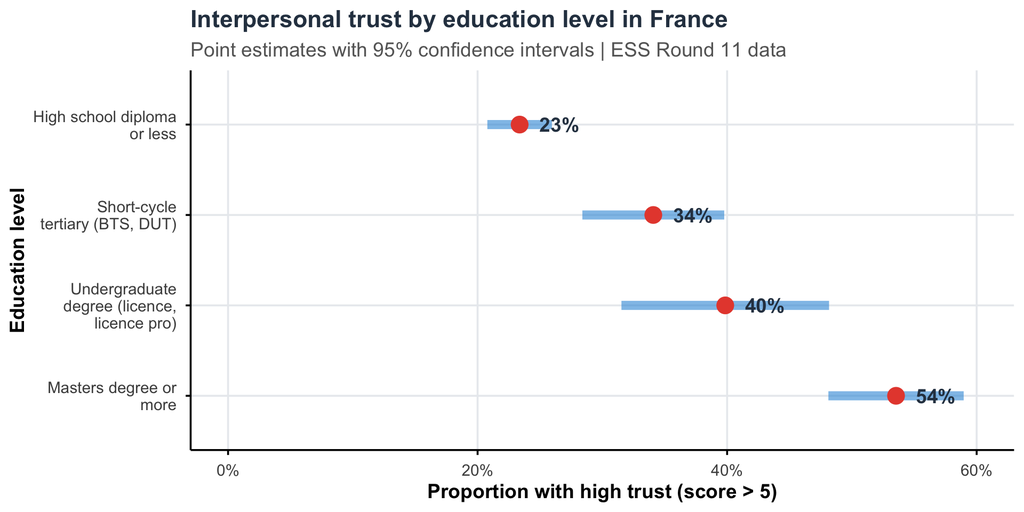

## Today’s lecture

**The big question:** We can compute sample statistics, but how confident should we be that they reflect the true population parameters?

1. Confidence intervals: a primer

2. CI for a population mean: theory-based

3. CI for a proportion: theory-based

**4. Bootstrap CI**

5. Comparing two groups

6. Practical guidelines

# Bootstrap CI

## Motivation: Why bootstrap?

**Limitations of CLT-based CIs:**

1. Require large samples for CLT to kick in
2. Assume specific parametric forms
3. Difficult for complex statistics (medians, ratios, correlations)

**The bootstrap idea:**

> If we can’t sample repeatedly from the population, let’s sample repeatedly from our sample!

**Key insight**

The sample is our best representation of the population. Resampling from the sample mimics sampling from the population.

## Bootstrap: the procedure

**Bootstrap Algorithm**

1. **Original sample:** Start with sample of size $n$
2. **Resample:** Draw $n$ observations with replacement
3. **Compute:** Calculate statistic of interest
4. **Repeat:** Do this $B$ times (typically $B \geq 1000$)
5. **CI:** Two methods:
   - **Percentile method:** Use the 2.5th and 97.5th percentiles of bootstrap distribution
   - **SE method:** $\hat{\theta} \pm z_{\alpha/2} \times SE_{boot}$, where $SE_{boot}$ is the SD of bootstrap estimates

## Our original sample

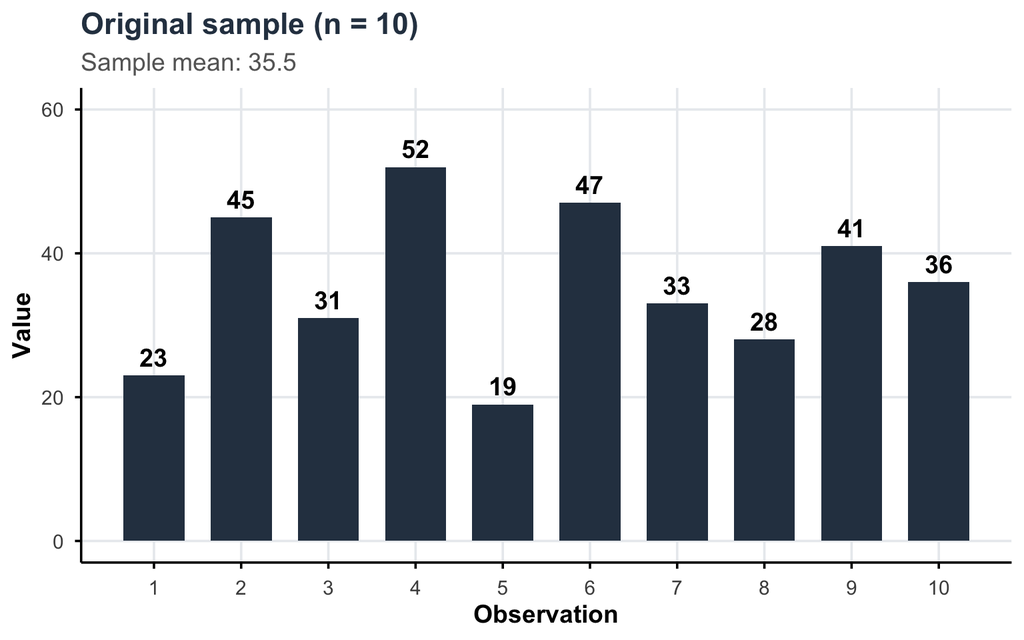

**Question:** How can we estimate the variability of $\bar{x}$ without taking new samples from the population?

## Building a bootstrap sample

We resample **with replacement** from our original sample:

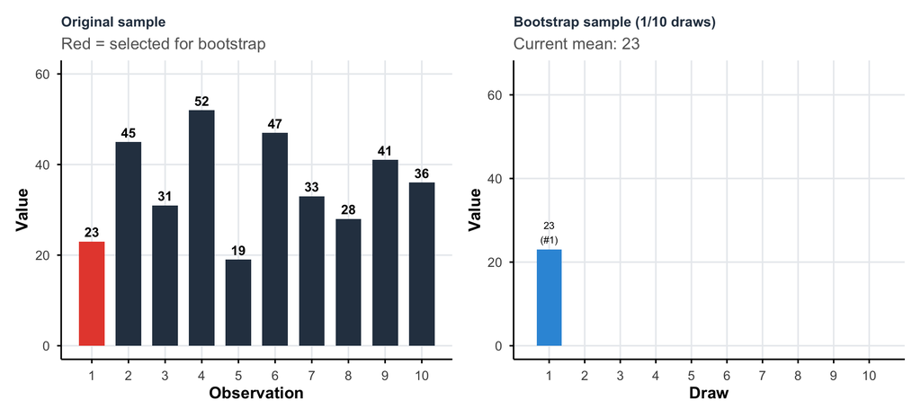

## Building a bootstrap sample

We resample **with replacement** from our original sample:

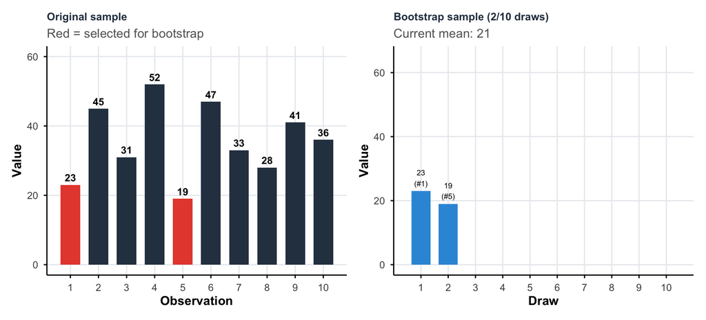

## Building a bootstrap sample

We resample **with replacement** from our original sample:

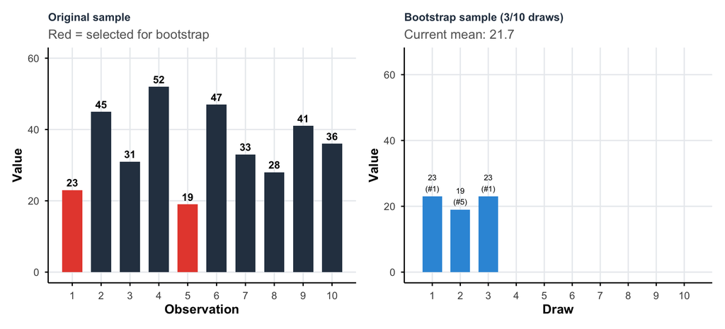

## Building a bootstrap sample

We resample **with replacement** from our original sample:

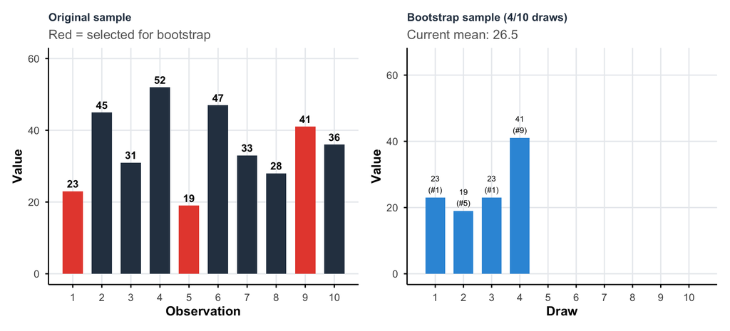

## Building a bootstrap sample

We resample **with replacement** from our original sample:

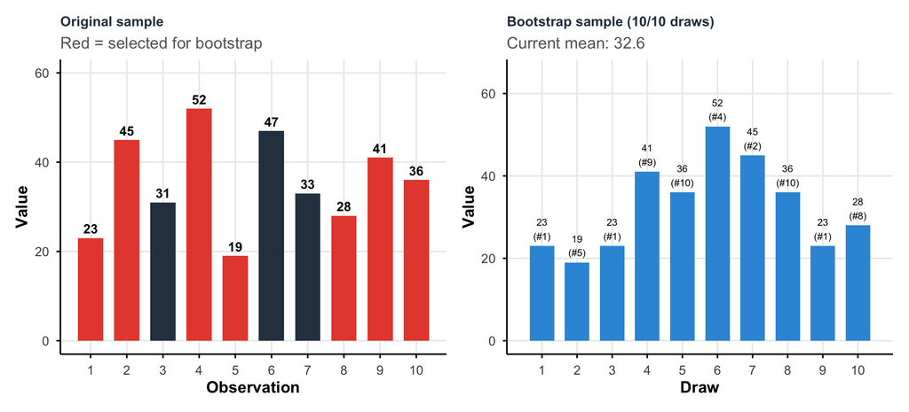

**Note**

Each draw is **independent** and **with replacement** — the same observation can be selected multiple times!

## Bootstrap resampling

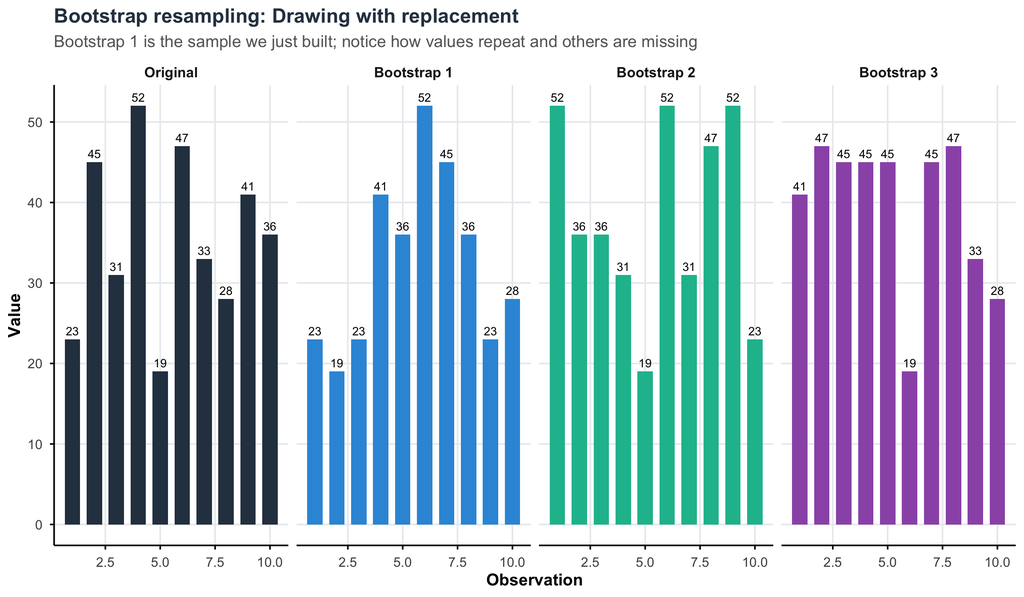

## Bootstrap in R with `infer`

- Let’s repeat the resampling procedure 1,000 times: there will be 1,000 bootstrap samples and 1,000 bootstrap estimates!
- We use the `infer` package to ease the bootstrapping procedure.

```r
# Using our working hours data
bootstrap_means <- ess_france_clean |>
  # specify the variable of interest
  specify(response = stflife) |>
  # generate 1000 bootstrap samples
  generate(reps = 1000, type = "bootstrap") |>
  # calculate the mean
  calculate(stat = "mean")
```

```r
# View first few bootstrap means
head(bootstrap_means)
```

```
Response: stflife (numeric)
# A tibble: 6 × 2
  replicate  stat
      <int> <dbl>
1         1  6.81
2         2  6.74
3         3  6.76
4         4  6.74
5         5  6.75
6         6  6.83
```

```r
nrow(bootstrap_means)
```

```
[1] 1000
```

## Bootstrap distribution

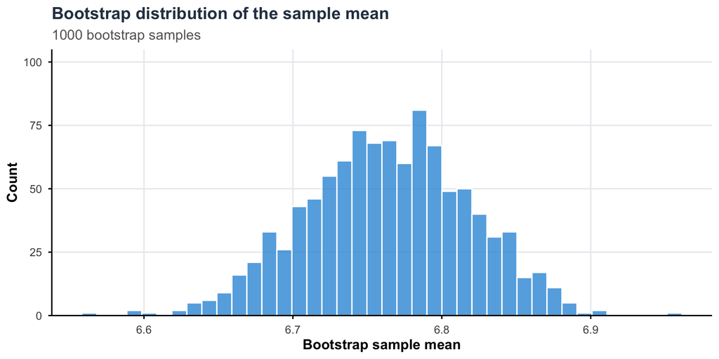

## Bootstrap distribution

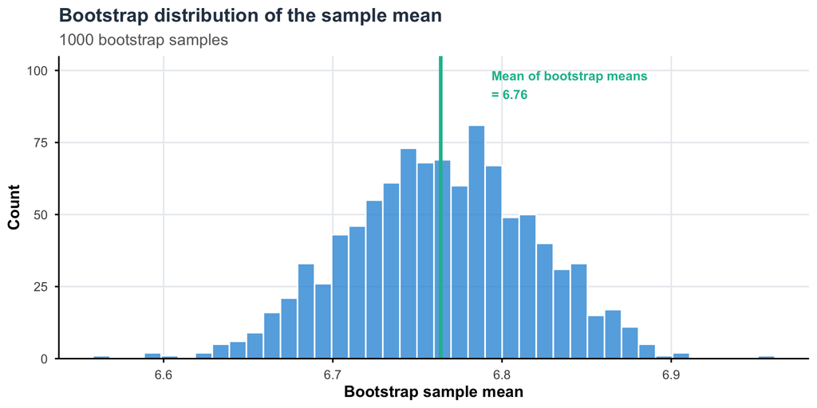

```r
mean(bootstrap_means$stat)
```

```
[1] 6.763766
```

## Bootstrap distribution

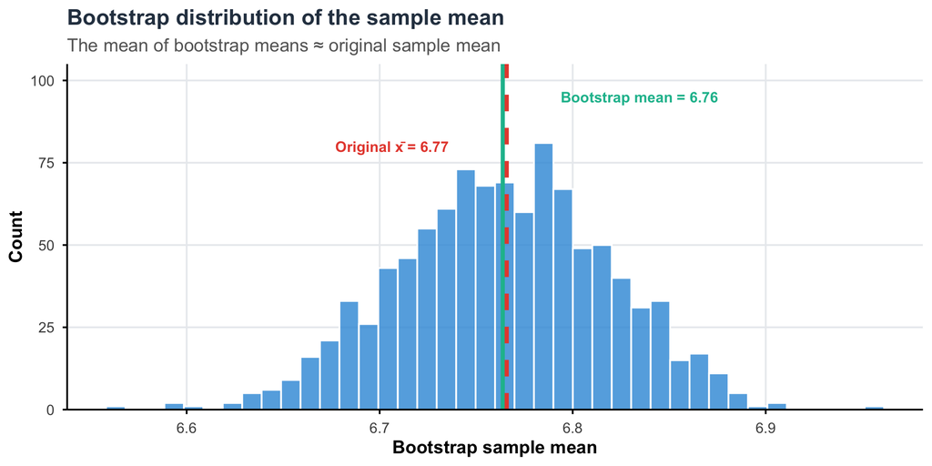

```r
mean(ess_france_clean$stflife)
```

```
[1] 6.765823
```

## Bootstrap distribution: Percentile CI

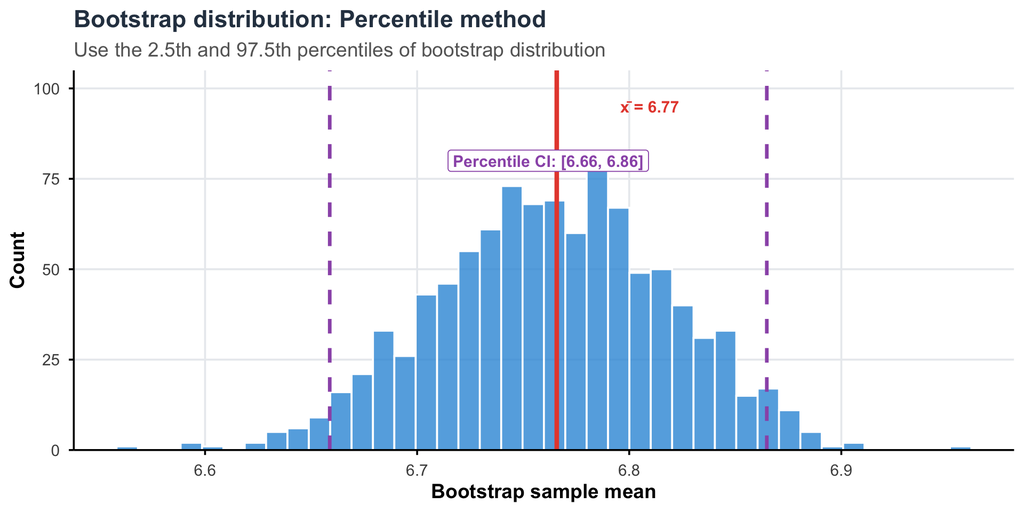

```r
quantile(bootstrap_means$stat, probs = c(0.025, 0.975))
```

```
    2.5%    97.5%
6.658789 6.864873
```

## Bootstrap distribution: SE method

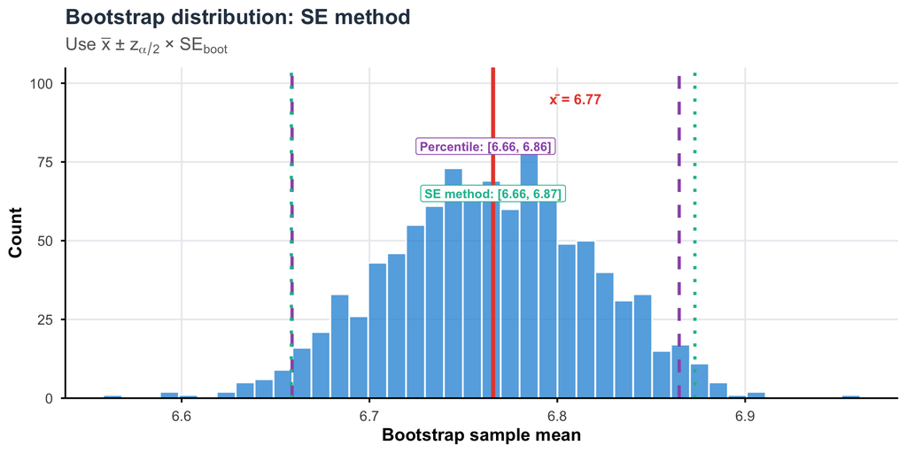

```r
mean(bootstrap_means$stat) + 1.96 * sd(bootstrap_means$stat)
```

```
[1] 6.871183
```

## Bootstrap distribution: Comparison with theory

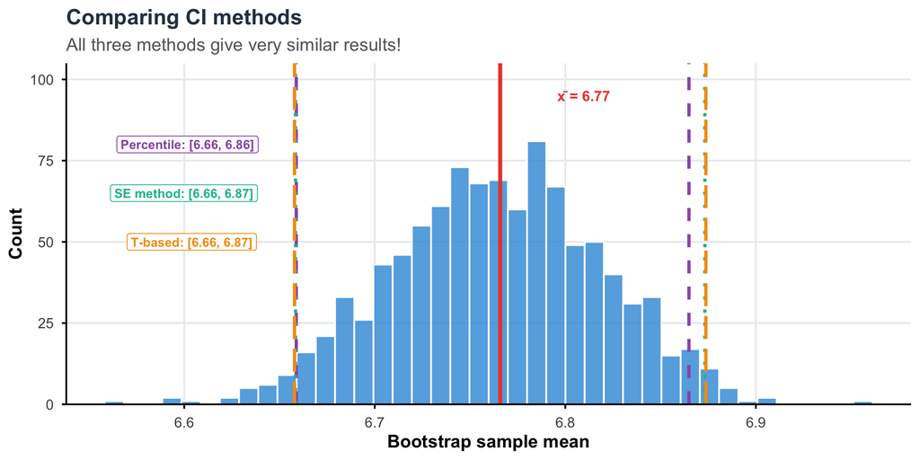

```r
mean(ess_france_clean$stflife) + 1.96 * sd(ess_france_clean$stflife)/sqrt(nrow(ess_france_clean))
```

```
[1] 6.873691
```

## Why the bootstrap works: Intuition

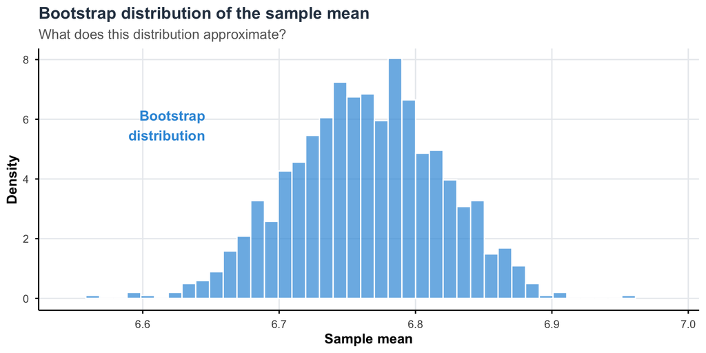

## Why the bootstrap works: Intuition

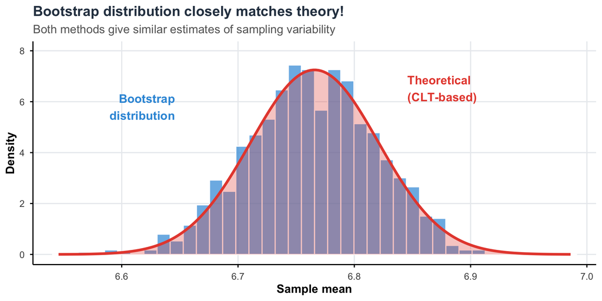

**The bootstrap principle:** The empirical distribution of the sample is a good approximation of the population distribution.

## Bootstrap for complex statistics

**The power of bootstrap:** Works for any statistic!

```r
# Bootstrap CI for the median
boot_median <- ess_france_clean %>%
  specify(response = stflife) %>%
  generate(reps = 1000, type = "bootstrap") %>%
  calculate(stat = "median")

boot_median %>% get_ci(level = 0.95, type = "percentile")
```

```
# A tibble: 1 × 2
  lower_ci upper_ci
     <dbl>    <dbl>
1        7        7
```

```r
# Bootstrap CI for the standard deviation
boot_sd <- ess_france_clean %>%
  specify(response = stflife) %>%
  generate(reps = 1000, type = "bootstrap") %>%
  calculate(stat = "sd")

boot_sd %>% get_ci(level = 0.95, type = "percentile")
```

```
# A tibble: 1 × 2
  lower_ci upper_ci
     <dbl>    <dbl>
1     2.20     2.38
```

## Your Turn! #3

1. Compute the sample mean, standard deviation, and standard error for satisfaction with democracy (`stfdem`) in the ESS France data.
2. Compute the t-based 95% CI for mean satisfaction manually and using `t.test()`.
3. Compute the bootstrap 95% CI using the `infer` package (use 1000 reps):

```r
bootstrap_stfdem <- ess_france_clean |>
  specify(response = stfdem) |>
  generate(reps = 1000, type = "bootstrap") |>
  calculate(stat = "mean")
```

4. Visualize the bootstrap distribution with a histogram.
5. Compare the two methods — how similar are the CIs? Why might they differ?

## Today’s lecture

**The big question:** We can compute sample statistics, but how confident should we be that they reflect the true population parameters?

1. Confidence intervals: a primer

2. CI for a population mean: theory-based

3. CI for a proportion: theory-based

4. Bootstrap CI

**5. Comparing two groups**

6. Practical guidelines

# Comparing two groups

## Key distinctions in group comparisons

When comparing two groups, we need to consider three important dimensions:

**1. What are we comparing?**

- **Means:** Continuous variables (e.g., average income, test scores)
  - Use: t-tests, z-tests
- **Proportions:** Binary/categorical outcomes (e.g., % with high trust)
  - Use: proportion tests

**2. What do we know about variability?**

- **Known variance ($\sigma^2$):** rarely in practice, use z-distribution
  - $SE = \sqrt{\frac{\sigma_1^2}{n_1} + \frac{\sigma_2^2}{n_2}}$
- **Unknown variance:** most realistic case, use t-distribution
  - $SE = \sqrt{\frac{s_1^2}{n_1} + \frac{s_2^2}{n_2}}$

## Key distinctions in group comparisons

**3. How are the samples related?**

- **Independent samples:** Two separate groups (e.g., men vs women, treatment vs control)
  - Standard errors add: $SE(\bar{x}_1 - \bar{x}_2) = \sqrt{SE_1^2 + SE_2^2}$
- **Dependent samples:** Paired/matched observations (e.g., before-after, twins)
  - Analyze differences: $\bar{d} = \frac{1}{n}\sum(x_i - y_i)$, then $SE(\bar{d}) = \frac{s_d}{\sqrt{n}}$

## CI for difference in means

**Question:** Is there a difference in life satisfaction between men and women in France?

**Setup:**

- Population 1 (men): mean $\mu_M$, sample mean $\bar{x}_M$, sample size $n_M$
- Population 2 (women): mean $\mu_F$, sample mean $\bar{x}_F$, sample size $n_F$

**Parameter of interest:** $\mu_M - \mu_F$

**Independent samples:** the two samples are independent (pretty reasonable)

**CI for Difference in Means (known $\sigma$)**

$$(\bar{x}_1 - \bar{x}_2) \pm z_{\alpha/2} \times \sqrt{\frac{\sigma_M^2}{n_M} + \frac{\sigma_F^2}{n_F}}$$

## CI for difference in means

**Question:** Is there a difference in life satisfaction between men and women in France?

**Setup:**

- Population 1 (men): mean $\mu_M$, sample mean $\bar{x}_M$, sample size $n_M$
- Population 2 (women): mean $\mu_F$, sample mean $\bar{x}_F$, sample size $n_F$

**Parameter of interest:** $\mu_M - \mu_F$

**Independent samples:** the two samples are independent (pretty reasonable)

**CI for Difference in Means (unknown $\sigma$)**

$$(\bar{x}_1 - \bar{x}_2) \pm t_{\alpha/2,df} \times \sqrt{\frac{s_1^2}{n_1} + \frac{s_2^2}{n_2}}$$

## Welch–Satterthwaite df

**CI for Difference in Means (unknown $\sigma$)**

$$(\bar{x}_1 - \bar{x}_2) \pm t_{\alpha/2,df} \times \sqrt{\frac{s_1^2}{n_1} + \frac{s_2^2}{n_2}}$$

The degrees of freedom $(df)$ is this case is given by the **Welch–Satterthwaite** equation:

$$df = \frac{\left(\frac{s_M^2}{n_M} + \frac{s_F^2}{n_F}\right)^2}{\frac{\left(\frac{s_M^2}{n_M}\right)^2}{n_M-1} + \frac{\left(\frac{s_F^2}{n_F}\right)^2}{n_F-1}}$$

This is what `t.test` does by default (see help).

## Special case: equal variance

If we assume $\sigma_M^2$ = $\sigma_F^2$, the pooled variance becomes:

$$\begin{align*}
\mathbb{V}(\bar{X}_M - \bar{X}_F) &= \mathbb{V}(\bar{X}_M) + \mathbb{V}(\bar{X}_F) \\
&= \frac{\sigma^2}{n_M} + \frac{\sigma^2}{n_F} \\
&= \sigma^2 \left(\frac{1}{n_M} + \frac{1}{n_F} \right)
\end{align*}$$

Natural unbiased **estimator** is a weighted average of the two sample variances:

$$s_p^2 = \frac{(n_M-1)s_M^2 + (n_F-1)s_F^2}{n_M+n_F-2}$$

$$\begin{align*}
&\Rightarrow \widehat{\mathbb{V}(\bar{X}_M - \bar{X}_F)} = s_p^2\left( \frac{1}{n_M} + \frac{1}{n_F} \right) \\
&\Rightarrow \boxed{\hat{SE}_{pooled} = s_p \sqrt{\left( \frac{1}{n_M} + \frac{1}{n_F} \right)}}
\end{align*}$$

The critical $t$-value has $n_M + n_F - 2$ degrees of freedom.

## Example: gender gap in life satisfaction

```r
# Compare life satisfaction by gender
gender_summary <- ess_france_clean |>
  mutate(gender = ifelse(gndr == 1, "male", "female")) |>
  summarise(n = n(),
            mean = mean(stflife),
            sd = sd(stflife),
            se = sd^2 / n, .by = gender) |>
  pivot_wider(names_from = gender,
              values_from = c(n, mean, sd, se))

diff_mean = gender_summary$mean_male - gender_summary$mean_female
n_m = gender_summary$n_male
n_f = gender_summary$n_female
var_m = gender_summary$sd_male^2
var_f = gender_summary$sd_female^2
se_m = gender_summary$se_male
se_f = gender_summary$se_female
se_pooled = sqrt(se_m + se_f)
df_welch = (se_m + se_f)^2/(((se_m)^2/(n_m -1)) + ((se_f)^2/(n_f -1)))

t_stat = qt(0.975, df = df_welch)
c(diff_mean - t_stat * se_pooled, diff_mean + t_stat * se_pooled)
```

```
[1] -0.07055206  0.36130738
```

```r
# Two-sample t-test
t.test(stflife ~ gndr, data = ess_france_clean)
```

```
    Welch Two Sample t-test

data:  stflife by gndr
t = 1.3205, df = 1730.8, p-value = 0.1868
alternative hypothesis: true difference in means between group 1 and group 2 is not equal to 0
95 percent confidence interval:
 -0.07055206  0.36130738
sample estimates:
mean in group 1 mean in group 2
       6.839348        6.693970
```

## Visualizing the difference

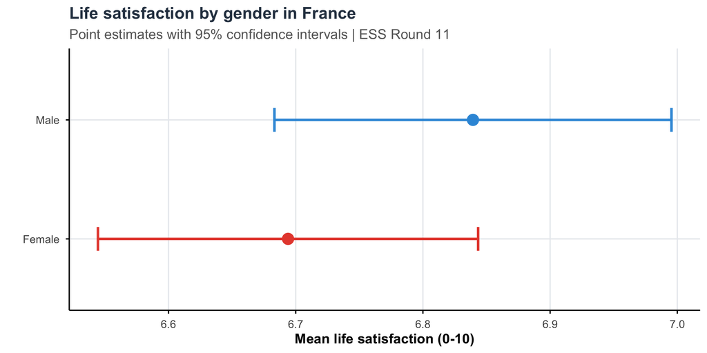

**Interpretation:** If the CIs overlap substantially, we can’t confidently conclude the means differ.

## Bootstrap for difference in means

```r
# Bootstrap approach
boot_diff <- ess_france_clean |>
  mutate(gender = ifelse(gndr == 1, "Male", "Female")) |>
  specify(stflife ~ gender) |>
  generate(reps = 1000, type = "bootstrap") |>
  calculate(stat = "diff in means", order = c("Male", "Female"))

# Get CI
boot_diff |> get_ci(level = 0.95, type = "percentile")
```

```
# A tibble: 1 × 2
  lower_ci upper_ci
     <dbl>    <dbl>
1  -0.0542    0.376
```

## CI for difference in means: paired samples

**When samples are dependent (paired):**

- **Paired data:** Two measurements on the same individuals (before/after, twins, matched pairs)
- Ex: pre-test vs post-test scores, trust in parliament vs trust in politicians

**Key insight:** instead of comparing two independent samples, we analyze the differences within each pair!

**Approach:**

1. Compute differences: $d_i = x_i - y_i$ for each pair
2. Calculate mean difference: $\bar{d} = \frac{1}{n}\sum_{i=1}^n d_i$
3. Calculate SD of differences: $s_d = \sqrt{\frac{1}{n-1}\sum_{i=1}^n(d_i - \bar{d})^2}$

## CI for difference in means: paired samples

**CI for Paired Difference in Means**

$$\bar{d} \pm t_{\alpha/2, n-1} \times \frac{s_d}{\sqrt{n}}$$

## Example: trust in parliament vs politicians

**Question:** Do French adults trust parliament more than politicians?

```r
# Prepare paired data (trust in parliament vs trust in politicians)
ess_paired <- ess_france_clean |>
  filter(!trstprl %in% c(77, 88),  # trust parliament
         !trstplt %in% c(77, 88))   # trust politicians

# Create differences
ess_paired <- ess_paired %>%
  mutate(diff = trstprl - trstplt)  # positive = more trust in parliament

# Summary
ess_paired |>
  summarise(mean_parliament = mean(trstprl),
            mean_politicians = mean(trstplt),
            mean_difference = mean(diff))
```

```
  mean_parliament mean_politicians mean_difference
1        4.158269         3.766449       0.3918198
```

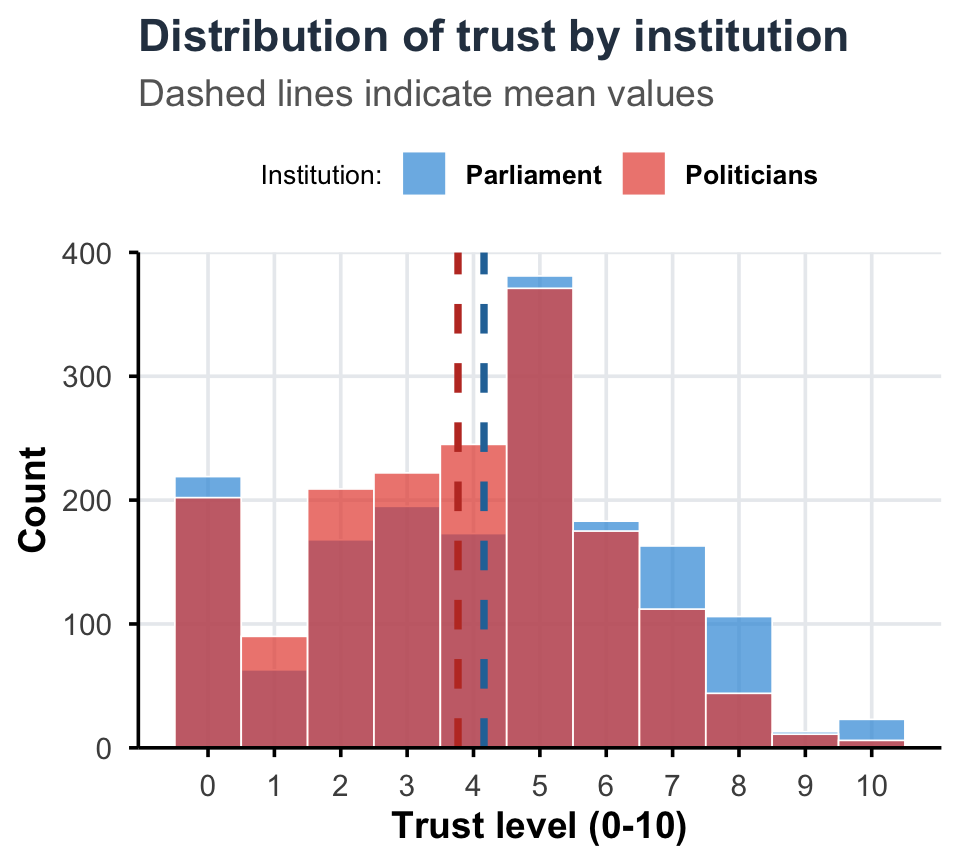

**Question:** is there a difference between these two variables?

## Manual calculation: Paired t-test

```r
# Summary statistics
n_paired <- nrow(ess_paired)
mean_diff <- mean(ess_paired$diff)
sd_diff <- sd(ess_paired$diff)
se_diff <- sd_diff / sqrt(n_paired)

t_crit <- qt(0.975, df = n_paired - 1)

ci_lower <- mean_diff - t_crit * se_diff
ci_upper <- mean_diff + t_crit * se_diff

c(ci_lower, ci_upper)
```

```
[1] 0.2956501 0.4879895
```

**Interpretation:** We are 95% confident that French adults trust parliament between 0.3 and 0.49 points more than politicians (on a 0-10 scale).

## Using `t.test()` for paired samples

```r
# Using t.test with paired = TRUE
t.test(ess_paired$trstprl, ess_paired$trstplt,
       paired = TRUE,
       conf.level = 0.95)
```

```
    Paired t-test

data:  ess_paired$trstprl and ess_paired$trstplt
t = 7.9911, df = 1686, p-value = 2.457e-15
alternative hypothesis: true mean difference is not equal to 0
95 percent confidence interval:
 0.2956501 0.4879895
sample estimates:
mean difference
      0.3918198
```

**Why does pairing matter?**

- Paired design controls for individual differences (some people are generally more/less trusting)
- This reduces variability and gives more precise estimates
- More statistical power to detect differences!

## CI for difference in proportions: Theory

**Setting:** We want to compare proportions between two independent groups

- Group 1: proportion $p_1$, sample proportion $\hat{p}_1$, sample size $n_1$
- Group 2: proportion $p_2$, sample proportion $\hat{p}_2$, sample size $n_2$

**Parameter of interest:** $p_1 - p_2$

**Sampling distribution:**

By the CLT (for large samples), each sample proportion follows:

$$\hat{p}_1 \sim \mathcal{N}\left(p_1, \frac{p_1(1-p_1)}{n_1}\right) \quad \text{and} \quad \hat{p}_2 \sim \mathcal{N}\left(p_2, \frac{p_2(1-p_2)}{n_2}\right)$$

Therefore, the difference follows:

$$\hat{p}_1 - \hat{p}_2 \sim \mathcal{N}\left(p_1 - p_2, \frac{p_1(1-p_1)}{n_1} + \frac{p_2(1-p_2)}{n_2}\right)$$

## CI for difference in proportions: Formula

**Standard error of the difference:**

$$SE(\hat{p}_1 - \hat{p}_2) = \sqrt{\frac{\hat{p}_1(1-\hat{p}_1)}{n_1} + \frac{\hat{p}_2(1-\hat{p}_2)}{n_2}}$$

**$(1-\alpha)$% Confidence Interval for $p_1 - p_2$**

$$(\hat{p}_1 - \hat{p}_2) \pm z_{\alpha/2} \times \sqrt{\frac{\hat{p}_1(1-\hat{p}_1)}{n_1} + \frac{\hat{p}_2(1-\hat{p}_2)}{n_2}}$$

**Rule of thumb for CLT validity:**

- $n_1\hat{p}_1 \geq 10$, $n_1(1-\hat{p}_1) \geq 10$
- $n_2\hat{p}_2 \geq 10$, $n_2(1-\hat{p}_2) \geq 10$

## CI for difference in proportions: Example

**Question:** Is the proportion of people with high interpersonal trust different by gender?

```r
# Create binary variable for high trust (> 5 on 0-10 scale)
ess_trust <- ess_france_clean |>
  filter(!ppltrst %in% c(77, 88)) |>
  mutate(high_trust = ppltrst > 5,
         gender = ifelse(gndr == 1, "Male", "Female"))

# Compare proportions by gender
prop_comparison <- ess_trust |>
  summarise(n = n(),
            p = mean(high_trust),
            se = sqrt(p * (1 - p) / n),
            .by = gender)
prop_comparison
```

```
  gender   n         p         se
1   Male 855 0.3403509 0.01620455
2 Female 872 0.2993119 0.01550837
```

## Visualizing proportions with confidence intervals

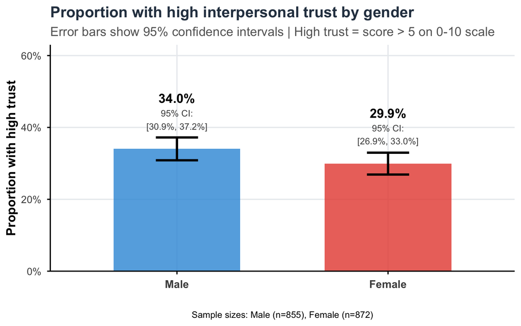

**Interpretation:** The confidence intervals overlap substantially, suggesting no significant difference in high trust proportions between males and females in France.

## CI for difference in proportions: Example

**Question:** Is the proportion of people with high interpersonal trust different by gender?

```r
# Two-sample proportion test
male_trust <- sum(ess_trust$high_trust[ess_trust$gender == "Male"])
female_trust <- sum(ess_trust$high_trust[ess_trust$gender == "Female"])
n_male <- sum(ess_trust$gender == "Male")
n_female <- sum(ess_trust$gender == "Female")

diff_trust <- male_trust/n_male - female_trust/n_female
se = sqrt((male_trust/n_male * (1 - male_trust/n_male))/n_male + (female_trust/n_female * (1 - female_trust/n_female))/n_female)

c(diff_trust - 1.96 * se, diff_trust + 1.96 * se)
```

```
[1] -0.002923497  0.085001398
```

```r
prop.test(c(male_trust, female_trust), c(n_male, n_female))
```

```
    2-sample test for equality of proportions with continuity correction

data:  c(male_trust, female_trust) out of c(n_male, n_female)
X-squared = 3.1574, df = 1, p-value = 0.07559
alternative hypothesis: two.sided
95 percent confidence interval:
 -0.004080879  0.086158780
sample estimates:
   prop 1    prop 2
0.3403509 0.2993119
```

## Your turn! #4

Using the same data as for `Your Turn #2` (slide 35), investigate whether interpersonal trust (`ppltrst`) differs by education level.

```r
ess_trust_educ <- ess_france |>
  filter(!ppltrst %in% c(77, 88),
         education != "") |>
  mutate(high_trust = ppltrst > 5,
         edu_cat = case_when(education == "High school diploma or less" ~ "High school diploma or less",
                             education != "High school diploma or less" ~ "Some higher eduation or more"))
```

## Today’s lecture

**The big question:** We can compute sample statistics, but how confident should we be that they reflect the true population parameters?

1. Confidence intervals: a primer

2. CI for a population mean: theory-based

3. CI for a proportion: theory-based

4. Bootstrap CI

5. Comparing two groups

**6. Practical guidelines**

# Practical guidelines

## When to use which method?

| Method | Best for | Requirements |
| --- | --- | --- |
| **z-interval** | Large n, known σ | n > 30, σ known |
| **t-interval** | Means, unknown σ | Approx. normal or n > 30 |
| **Proportion z** | Proportions | np ≥ 10, n(1-p) ≥ 10 |
| **Bootstrap** | Any statistic | Representative sample |

## Common mistakes to avoid

**Don’t say:**

❌ “There’s a 95% probability the true mean is in this interval”

❌ “95% of the data falls in this interval”

❌ “If we repeated this study, we’d get the same interval 95% of the time”

**Do say:**

✅ “We are 95% confident that the true mean is between X and Y”

✅ “This interval was constructed using a procedure that captures the true parameter 95% of the time”

## Reporting confidence intervals

**Good practice in reporting:**

**Include:**

1. Point estimate
2. CI bounds with confidence level
3. Sample size
4. Data source and time period

## Summary: key formulas

| Parameter | Point Estimate | Standard Error | CI Formula |
| --- | --- | --- | --- |
| Mean (σ known) | $\bar{x}$ | $\sigma/\sqrt{n}$ | $\bar{x} \pm z^* \cdot \frac{\sigma}{\sqrt{n}}$ |
| Mean (σ unknown) | $\bar{x}$ | $s/\sqrt{n}$ | $\bar{x} \pm t^* \cdot \frac{s}{\sqrt{n}}$ |
| Proportion | $\hat{p}$ | $\sqrt{\frac{\hat{p}(1-\hat{p})}{n}}$ | $\hat{p} \pm z^* \cdot SE$ |
| Diff. in means | $\bar{x}_1 - \bar{x}_2$ | $\sqrt{\frac{s_1^2}{n_1} + \frac{s_2^2}{n_2}}$ | $(\bar{x}_1 - \bar{x}_2) \pm t^* \cdot SE$ |
| Diff. in proportions | $\hat{p}_1 - \hat{p}_2$ | $\sqrt{\frac{\hat{p}_1(1-\hat{p}_1)}{n_1} + \frac{\hat{p}_2(1-\hat{p}_2)}{n_2}}$ | $(\hat{p}_1 - \hat{p}_2) \pm z^* \cdot SE$ |

## Your turn! #5

**Putting it all together** (15 minutes)

Design and conduct a complete analysis:

1. **Choose a question:** Pick one substantive question using the ESS France data
2. **Compute the CI:** Use both CLT-based and bootstrap methods
3. **Visualize:** Create an informative plot showing your results
4. **Interpret:** Write a paragraph interpreting your findings

**Examples:**

- Compare trust in police (`trstplc`) between age groups
- Analyze happiness (`happy`) by gender
- Investigate feelings about the economy (`stfeco`) across education levels